# Uniad 4: Límites y Continuidad (Parte 2)

**Objetivos:** Practicar el cálculo de límites por sustitución directa y, en el caso de que estén indeterminados, aplicando diversas propiedades matemáticas. Practicar ejercicios sobre continuidad de funciones.

**Fuentes:** Se combinan contenidos de “Khan Academy” y del libro “Logikamente” que ya vienes usando. En Khan Academy esta unidad se llama “Límites y continuidad” y puedes consultarla en [[español](https://es.khanacademy.org/math/precalculus/x9e81a4f98389efdf:limits-and-continuity)] o en [[inglés](https://www.khanacademy.org/math/precalculus/x9e81a4f98389efdf:limits-and-continuity)].

**Carpeta:** Salvo que se diga algo contrario en algún ejercicio debes tenerlos todos resueltos en tu carpeta.

## Límites por sustitución directa

- 1- Resuelve estos ejercicios teniendo en cuenta que:
  - Si una función es continua en `x = x0` el límite de esa función para `x tendiendo a x0` es `f(xo)`. Puedes repasarlo [aquí](https://es.khanacademy.org/math/precalculus/x9e81a4f98389efdf:limits-and-continuity/x9e81a4f98389efdf:determining-limits-using-algebraic-properties-of-limits-direct-substitution/v/limit-by-substitution).
  - Si en un ejercicio el numerador tiende a un número finito y el denominador tiende a **cero** se dice que el límite no existe. Puedes repasarlo aquí.

## Determinar límites indeterminados usando manipulación algebraica

**Indeterminaciones más comunes:** Recuerda que cuando evalúas un límite puedes lllegar a expresiones como **“0/0”**, **“∞/∞”**, **“0∙∞”** o **“∞ - ∞”**. Se llaman indeterminaciones por que no es evidente si el límite “existe” o “no existe”. Para averiguarlo hay que manipular algebráicamente la función.

### Límites por medio de factorización

Aquí la clave está en factorizar numerador y denominador y luego simplificarlos. Puedes aplicar: - Diferencia de cuadrados - Calcular y usar raíces - Aplicar Ruffini (recomendado si aparecen polinomios de grado mayor a 2)

- 3- Resolver estos [ejercicios](https://es.khanacademy.org/math/precalculus/x9e81a4f98389efdf:limits-and-continuity/x9e81a4f98389efdf:determining-limits-using-algebraic-manipulation/e/two-sided-limits-using-algebra)
- 4- Resolver estos ejercicios del libro:

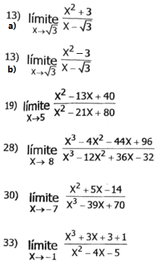

### Límites usando conjugados

- 5- Resuelve estos [ejercicios](https://es.khanacademy.org/math/precalculus/x9e81a4f98389efdf:limits-and-continuity/x9e81a4f98389efdf:determining-limits-using-algebraic-manipulation/e/limits_2). Puedes repasar el método [aquí](https://es.khanacademy.org/math/precalculus/x9e81a4f98389efdf:limits-and-continuity/x9e81a4f98389efdf:determining-limits-using-algebraic-manipulation/v/limits-by-rationalizing).
- 6- Resolver estos ejercicios del libro. Si no salvas la indeterminación sigue aplicando otros métodos hasta sacarla:

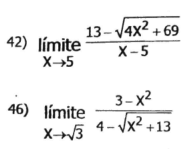

- 7- Ejercicio 43 del libro. Este es opcional, puedes hacerlo o no, tiene una dificultad parecida al 42.

### Límites usando identidades trigonométricas

**Identidades más comunes:**

- Identidad Pitagórica: **sin²(θ) + cos²(θ) = 1**
- Identidades Recíprocas: **csc(θ) = 1/sin(θ)**; **sec(θ) = 1/cos(θ)** y **cot(θ) = 1/tan(θ)**
- Identidad Tangente: **tan(θ) = sin(θ)/cos(θ)**
- Identidades de Ángulo Doble:
  - **sin(2θ) = 2sin(θ)cos(θ)**
  - **cos(2θ) = cos²(θ) - sin²(θ)**
- Identidades de Suma y Resta:
  - **sin(α ± β) = sin(α)cos(β) ± cos(α)sin(β)**
  - **cos(α ± β) = cos(α)cos(β) ∓ sin(α)sin(β)**
- 8- Resuelve estos [ejercicios](https://es.khanacademy.org/math/precalculus/x9e81a4f98389efdf:limits-and-continuity/x9e81a4f98389efdf:determining-limits-using-algebraic-manipulation/e/find-limits-using-trig-identities). Puedes repasar ésto [aquí](https://es.khanacademy.org/math/precalculus/x9e81a4f98389efdf:limits-and-continuity/x9e81a4f98389efdf:determining-limits-using-algebraic-manipulation/v/trig-limit-using-pythagorean-identity) y [aquí](https://es.khanacademy.org/math/precalculus/x9e81a4f98389efdf:limits-and-continuity/x9e81a4f98389efdf:determining-limits-using-algebraic-manipulation/v/trig-limit-using-double-angle-identity).
- 9- Recordando que hay límites especiales, conocidos, como `límite de 'sen(x)/x' cuando x tiende a 0` y `límite de 'tg(x)/x' cuando x tiende a 0` resuelve los siguientes problemas del libro. Sugerencia: Verifica siempre primero si hay indeterminación*.

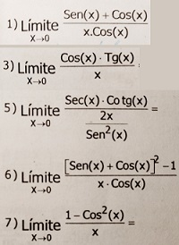

## Continuidad de una función

- Una función es continua cuando es continua en todos los puntos de su dominio.
- Una función es continua en un punto cuando:
  - Existe el límite de la función en ese punto
  - Existe la función en ese punto
  - Ambos valores son iguales
- 10- [Clasifica](https://es.khanacademy.org/math/precalculus/x9e81a4f98389efdf:limits-and-continuity/x9e81a4f98389efdf:exploring-types-of-discontinuities/e/analyzing-discontinuities-graphical) estas discontinuidades observando las gráficas de las funciones. Puedes repasar esto [aquí](https://es.khanacademy.org/math/precalculus/x9e81a4f98389efdf:limits-and-continuity/x9e81a4f98389efdf:exploring-types-of-discontinuities/v/types-of-discontinuities). No hace falta que escribas este ejercicio en la carpeta.
- 11- [Analiza](https://es.khanacademy.org/math/precalculus/x9e81a4f98389efdf:limits-and-continuity/x9e81a4f98389efdf:defining-continuity-at-a-point/e/analyze-continuity-at-a-point-graphically) la continuidad de estas funciones gráficamente.No hace falta que escribas este ejercicio en la carpeta.
- 12- [Resuelve](https://es.khanacademy.org/math/precalculus/x9e81a4f98389efdf:limits-and-continuity/x9e81a4f98389efdf:defining-continuity-at-a-point/e/continuity-at-a-point-algebraic) algebráicamente estos ejercicios de continuidad. Plantea en tu carpeta cada límite y resuélvelos para llegar a la conclusión correcta. Puedes repasar esto [aquí](https://es.khanacademy.org/math/precalculus/x9e81a4f98389efdf:limits-and-continuity/x9e81a4f98389efdf:defining-continuity-at-a-point/v/limit-of-piecewise-function-that-is-defined) y [aquí](https://es.khanacademy.org/math/precalculus/x9e81a4f98389efdf:limits-and-continuity/x9e81a4f98389efdf:defining-continuity-at-a-point/v/limit-of-piecewise-function-that-is-undefined).

## Conexión entre límites y asíntotas

Una asíntota es una recta que en el infinito tiende a cortarse con la gráfica de la función.

### Conexión de límites y asíntotas verticales

Si el límite de una función para x tendiendo a `x0` no está acotado, o es infinito, o es menos infinito, entonces la función tiene una asíntota vertical en `x = x0`.

- 13- [Resuelve](https://es.khanacademy.org/math/precalculus/x9e81a4f98389efdf:limits-and-continuity/x9e81a4f98389efdf:connecting-infinite-limits-and-vertical-asymptotes/e/unbounded-limits-graphical) estos límites en donde hay asíntotas verticales gráficamente. Siempre que hay una asíntota vertical el límite no existe en ese punto pero también se puede matizar que en algunos casos tiende a infinito, a menos infinito o que simplemente no está acotado. [Aquí](https://es.khanacademy.org/math/precalculus/x9e81a4f98389efdf:limits-and-continuity/x9e81a4f98389efdf:connecting-infinite-limits-and-vertical-asymptotes/v/introduction-to-infinite-limits) puedes repasar estos matices y [aquí](https://es.khanacademy.org/math/precalculus/x9e81a4f98389efdf:limits-and-continuity/x9e81a4f98389efdf:connecting-infinite-limits-and-vertical-asymptotes/v/infinite-limits-and-asymptotes) como se relacionan los límites con las asíntotas. Elije uno solo de estos ejercicios y pásalo prolijamente a la carpeta.

### Conexión de límites y asíntotas horizontales

Las asíntotas horizontales existen cuando el límite de una función para x tendiendo a `infinito` y/o `menos infinito` es igual a un número finito.

- 14- [Resuelve](https://es.khanacademy.org/math/precalculus/x9e81a4f98389efdf:limits-and-continuity/x9e81a4f98389efdf:connecting-limits-at-infinity-and-horizontal-asymptotes/e/limits-at-infinity-graphical) estos ejercicios en donde hay asíntotas horizontales gráficamente. Puedes repasar [aquí](https://es.khanacademy.org/math/precalculus/x9e81a4f98389efdf:limits-and-continuity/x9e81a4f98389efdf:connecting-limits-at-infinity-and-horizontal-asymptotes/v/introduction-to-limits-at-infinity) como se relacionan las asíntotas horizontales con los límites. Elije uno solo de estos ejercicios y pásalo prolijamente a la carpeta.
- 15- [Resuelve](https://es.khanacademy.org/math/precalculus/x9e81a4f98389efdf:limits-and-continuity/x9e81a4f98389efdf:connecting-limits-at-infinity-and-horizontal-asymptotes/e/limits-at-infinity-where-x-is-unbounded) estos límites en donde x tiende a `infinito` o `menos infinito` en la carpeta. Puedes repasar esto [aquí](https://es.khanacademy.org/math/precalculus/x9e81a4f98389efdf:limits-and-continuity/x9e81a4f98389efdf:connecting-limits-at-infinity-and-horizontal-asymptotes/v/more-limits-at-infinity).